# Identifying Priority EEZ Regions for Oyster and Lingcod Aquaculture Using SST and Bathymetric Data

Using environmental suitability modeling to identify the best Exclusive Economic Zones (EEZs) for developing marine aquaculture.

R

Geospatial Analysis

Aquaculture

Author

Affiliation

[Ixel M.](https://IIDonaji.github.io/)

Master of Environmental Data Science Program @ The Bren School (UCSB)

Published

December 12, 2025

## Purpose

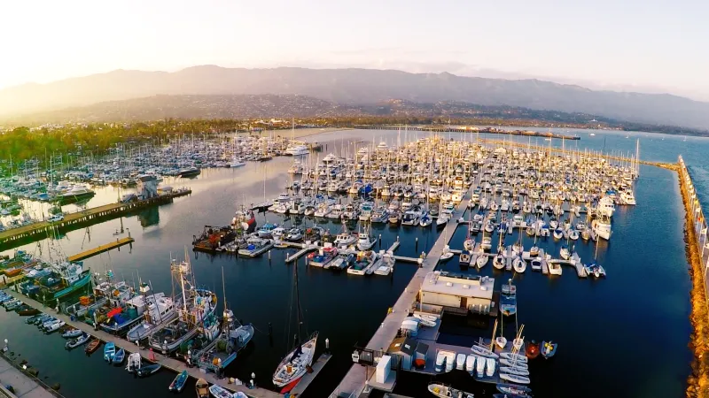

**Image: Commercial Fishing Boats, Santa Barbara Harbor, California, USA.**

Marine aquaculture is rapidly expanding as coastal nations seek sustainable ways to meet seafood demand. Identifying *where* aquaculture should occur is a major challenge optimal sites must balance ecological suitability, production needs, and regulatory boundaries.

### Research Question:

What Exclusive Economic Zones (EEZ) on the West Coast of the US are best suited to developing marine aquaculture for several species of oysters and Lingcod *Ophiodon elongatus* (Girard, 1854)?

### Data Sources

I combined three geospatial datasets:

- **Bathymetry:** GEBCO 2022 global depth raster
- **Sea Surface Temperature (SST):** 2008–2012 annual averages
- **Exclusive Economic Zones:** Cleaned U.S. West Coast EEZ shapefile

Environmental requirements were taken from fisheries and species-specific literature, including FishBase [(2025)].

All geospatial processing was performed in **R** using `terra`, `stars`, and `sf`.

## Methods

Key geospatial techniques included combining vector and raster data, resampling rasters to a common resolution, masking by jurisdictional boundaries, and applying map algebra to identify jointly suitable habitat.

#### 1. Prepare SST and Depth Data

Certain packages were required prior to the analysis. I loaded in the necessary libraries to proceed with data importation. Then, I read in the depth and EEZ shapefiles using `read_stars` and `st_read`, respectively, Finally, I stacked five annual SST rasters (2008–2012) using `rast()`.

It was also important to cross reference each spatial object so that each coordinate reference system (CRS) matches to prevent misalignment (refer to repository linked above for additional information).

Here, I calculated the mean SST using `app()` across all year rasters, then converted temperatures from Kelvin to Celsius.

```r
# Calculate the SST average
mean_sst <- app(sst[[c("average_annual_sst_2008",
                           "average_annual_sst_2009",
                           "average_annual_sst_2010",
                           "average_annual_sst_2011",
                           "average_annual_sst_2012")]],
                    fun = mean, na.rm = TRUE)

# Convert average SST from Kelvin to Celsius
sst_mean_celsius <- mean_sst - 273.15
```

Then, I cropped the bathymetry layer to the average SST raster and resampled to match the SST resolution.

```r
# First convert depth stars to SpatRaster
depth_rast <- rast(depth)

depth_resample <- depth_rast %>%
  crop(sst_mean_celsius) %>% # crop depth to match SST  extent
# Resample to match SST resolution, use method near
  resample(sst_mean_celsius,
           method = "near")
```

## Identify Suitable Habitat for Oysters

According to the literature, the following conditions are required for optimal growth in oyster species:

- **Sea Surface Temperature (SST) Range:** 11–30°C
- **Depth Range:** 0–70 m

Here, I classified suitable ranges for oyster-specific depth and SST by applying an if-else statement to categorize values based on a conditional. I assigned a value of 0 for values that fell outside the required range and assigned a value of 1 for values that were within the range.

```r
# Reclassify SST (11-30°C suitable for oysters)
sst_suitable <- app(sst_mean_celsius, fun = function(x){
  ifelse(x >= 11 & x <= 30,1,0) # if temperate is between 11- 30 °C, return 1, else 0
})

# Reclassify Suitable depth range (0-70 meters for oysters)
depth_suitable <- app(depth_resample, fun = function(x){
  ifelse(x >= -70 & x <= 0,1,0) # select depths from 0 to 70 meters below surface.
})

# Multiply the two suitability raster

suitable_locations <- sst_suitable * depth_suitable
```

## Quantify Suitable Area Within Each EEZ

I rasterized EEZ polygons, masked suitability values, and computed cell-area using zonal statistics. Here, I rasterized the EEZ shapefile based on suitable locations for each region (rgn). Then, I created a mask to isolate suitable locations within EEZs and summed the suitable area of each EEZ region.

```r
# Rasterize the EEZ data (creates zone IDs)
eez_raster <- rasterize(eez, suitable_locations, field = "rgn")
#Calculate cell area with cellSize()
cell_area <- cellSize(suitable_locations, unit = "km")
# Mask suitable locations to EEZ boundaries
suitable_area <- mask(suitable_locations, eez) * cell_area
# Sum suitable are by EEZ zonal statistics
eez_suitable <- zonal(suitable_area, eez_raster, fun = "sum", na.rm = TRUE)
```

## Results

**Oyster Suitability**

The highest-ranked region was Central California with about 4,940 km² of suitable area (~34% of all suitable habitat). The lowest ranked region was Northern California with about 454.30 km² (3.1% of all suitable area).

EEZ Rankings by Suitable Aquaculture Area

| Rank | EEZ Region | Suitable Area (km²) | % of Total |
| --- | --- | --- | --- |
| 1 | Central California | 4940.04 | 34.1 |
| 2 | Southern California | 4221.39 | 29.1 |
| 3 | Washington | 3313.16 | 22.8 |
| 4 | Oregon | 1578.97 | 10.9 |
| 5 | Northern California | 454.30 | 3.1 |

**Map 1.** Oyster Aquaculture Suitability by EEZ

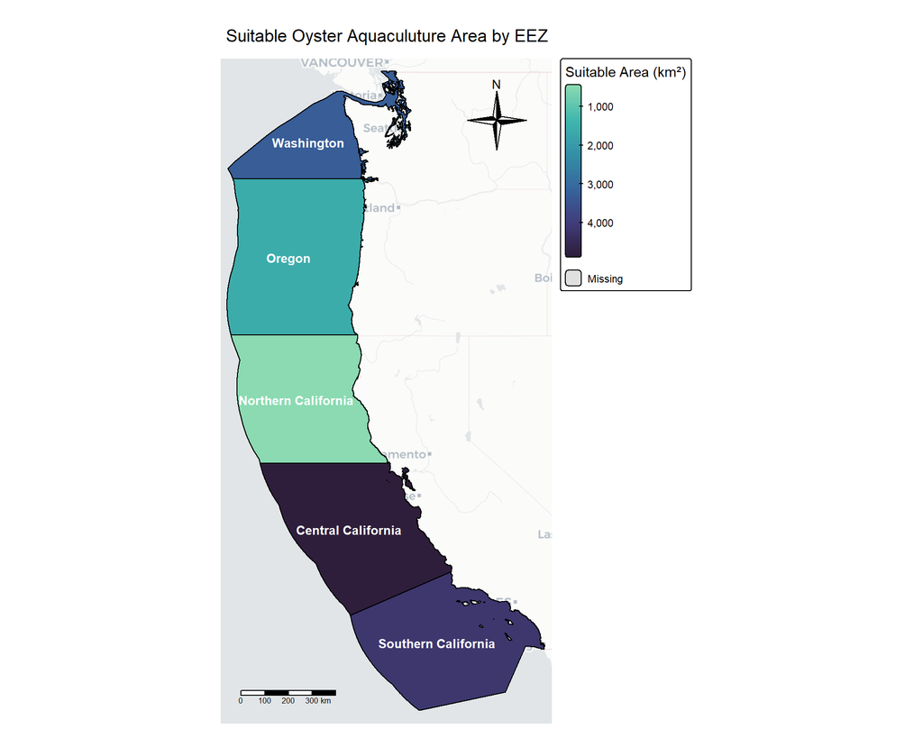

Suitable oyster aquaculture area by U.S. West Coast EEZ, based on mean SST (2008–2012) and bathymetric depth. Central California (CA-C) ranked highest with 4,940 km².

```r
# Map with tmap basic
# Map with tmap basic
tm_basemap("CartoDB.Positron", alpha = 0.7) +
tm_shape(eez_ranked) +
  tm_polygons("suitable_area_km2",
              palette = "-mako",
               style = "cont",
              title = "Suitable Area (km²)",
              border.col = "black",
              border.lwd = 0.5) +
  tm_layout(main.title = "Suitable Oyster Aquaculuture Area by EEZ",
            main.title.size = 1.2,
            legend.outside = TRUE,
            frame = FALSE) +
    tm_text("rgn", # Label by region
          size = .8, # Adjust size
          col = "white", # Adjust text color
          fontface = "bold", # Labels are bolded
          xmod = -.5) + # Adjust .5 from the left
  tm_compass(type = "4star", position = c("right", "top")) +
  tm_scalebar(position = c("left", "bottom"))
```

# Repeat previous steps with species of choice by creating a Function

[figure not shown]

**Image: Lingcod (*Ophiodon elongatus*), California Coast.**

Lingcod (*Ophiodon elongatus*) is one of the most commercially and recreationally important groundfish on the U.S. West Coast, prized for its firm white flesh, it’s the fish behind the classic Pacific fish and chips. Native from Alaska to Baja California, Lingcod are demersal predators that occupy rocky reef habitats at depths typically between 10–100 m and prefer cool temperate waters.

- **Sea Surface Temperature Range:** 7–18°C
- **Depth Range:** 0–100 m

The suitability workflow is generalizable to any species with documented SST and depth tolerances. Below, the same function is applied to Lingcod using its species-specific environmental ranges.

```r
# The function takes the following arguments:
# sst raster file
# depth raster file
# minimum and maximum sea surface temperature
# minimum and maximum depth
# species name

find_suitable_aquaculture <- function(sst_raster,
                                      depth_raster,
                                      eez_sf,
                                      sst_min,
                                      sst_max,
                                      depth_min,
                                      depth_max,
                                      species_name) {

# Reclassify SST
sst_suitable <- app(sst_raster, fun = function(x) {
    ifelse(x >= sst_min & x <= sst_max, 1, 0)
  })

# Reclassify depth
depth_suitable <- app(depth_raster, fun = function(x) {
    ifelse(x >= depth_min & x <= depth_max, 1, 0)
  })

# Find suitable locations (both conditions)
suitable_locations <- sst_suitable * depth_suitable
names(suitable_locations) <- species_name

# Mask to EEZ
suitable_in_eez <- mask(suitable_locations, eez_sf)

# Rasterize EEZ
eez_rasterize <- rasterize(eez_sf, suitable_locations, field = "rgn")

# Calculate cell areas
cell_area_km2 <- cellSize(suitable_locations, unit = "km")


# Calculate suitable area per cell (commented out for now)
suitable_area <- suitable_in_eez * cell_area_km2


# Sum by EEZ zone
eez_suitable_area <- zonal(
  suitable_area,
  eez_rasterize,
  fun = "sum",
  na.rm = TRUE)

colnames(eez_suitable_area) <- c("EEZ_ID", "Suitable_Area_km2")

# Join with EEZ data and rank
eez_sf$suitable_area_km2 <-
  eez_suitable_area$Suitable_Area_km2[
    match(eez_sf$rgn, eez_suitable_area$EEZ_ID)]
  eez_ranked <- eez_sf[order(-eez_sf$suitable_area_km2), ]

# Create summary table
summary_table <- data.frame(
   Rank = 1:nrow(eez_ranked),
    EEZ = eez_ranked$rgn,
    Suitable_Area_km2 = round(eez_ranked$suitable_area_km2, 2)
  )

# Return results as a list
results <- list(
   species = species_name,
  sst_suitable = sst_suitable,
   depth_suitable = depth_suitable,
   suitable_locations = suitable_locations,
   suitable_in_eez = suitable_in_eez,
   eez_ranked = eez_ranked,
    summary_table = summary_table
  )

 return(results)
}
```

## Lingcod Suitability Results

Here I apply `find_suitable_aquaculture()` to Lingcod using its cold-water, shallow demersal habitat requirements.

```r
# Lingcod suitable habitat
lingcod_results <- find_suitable_aquaculture(
  sst_raster = sst_mean_celsius,
  depth_raster = depth_resample,
  eez_sf = eez,
  sst_min = 7,
  sst_max = 18,
  depth_min = -100,
  depth_max = 0,
  species_name = "Lingcod"
)

# Access results
kable(lingcod_results$summary_table)
```

| Rank | EEZ | Suitable_Area_km2 |
| --- | --- | --- |
| 1 | Washington | 10569.13 |
| 2 | Oregon | 8317.53 |
| 3 | Central California | 7775.55 |
| 4 | Southern California | 6092.77 |
| 5 | Northern California | 5212.83 |

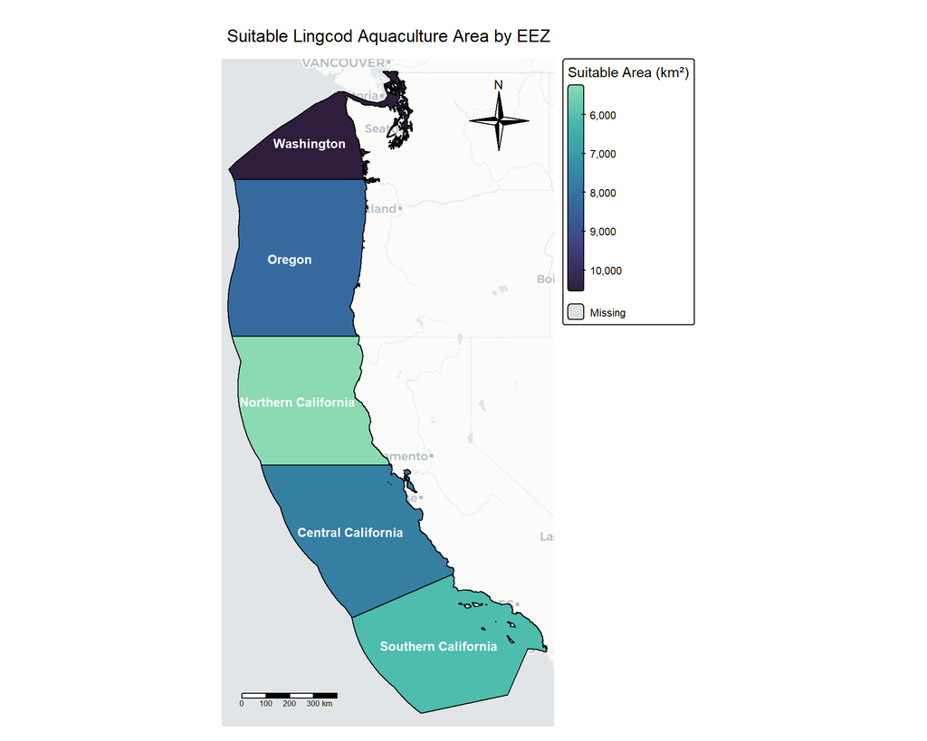

Suitable Lingcod aquaculture area by U.S. West Coast EEZ based on mean SST (2008–2012, 7–18°C) and depth (0–100 m). Washington ranked highest with 10,569 km².

```r
# Plot Crab EEZ
tm_basemap("CartoDB.Positron", alpha = 0.7) +
 tm_shape(lingcod_results$eez_ranked) +
  tm_polygons("suitable_area_km2",
              palette = "-mako",
              style = "cont",
              title = "Suitable Area (km²)",
              border.col = "black",
              border.lwd = 0.5) +
  tm_layout(main.title = "Suitable Lingcod Aquaculture Area by EEZ",
            main.title.size = 1.2,
            legend.outside = TRUE,
            frame = FALSE) +
  tm_text("rgn", # Label by region
          size = .8, # Adjust size
          col = "white", # Adjust text color
          fontface = "bold", # Labels are bolded
          xmod = -.5) + # Adjust .5 from the left
  tm_compass(type = "4star",
           position = c("right", "top")) +
tm_scale_bar(position = c("left", "bottom"))
```

## Discussion

Among the West Coast EEZs, **Central California ranked highest for oyster cultivation** with 4,940 km² of suitable area, reflecting its warmer nearshore SSTs and broad shallow shelf. **Northern California ranked lowest** at 454 km², where strong coastal upwelling keeps temperatures near the lower bound of oyster tolerance.

Lingcod showed a strikingly different spatial pattern. **Washington ranked first** with 10,569 km² of suitable habitat, followed by Oregon (8,318 km²) and Central California (7,776 km²). This northward shift reflects Lingcod’s cold-water preference, the cooler SSTs that limit oyster suitability in Washington and Oregon fall squarely within Lingcod’s optimal thermal range. Together, the two species illustrate how environmental tolerances drive fundamentally different regional priorities for aquaculture development.

Several limitations apply. SST and depth alone cannot capture substrate type, Lingcod strongly prefer rocky reef habitat, which this analysis cannot resolve. Marine protected areas, tribal waters, harmful algal bloom frequency, and shipping lane conflicts are also unaccounted for. Future analyses could incorporate substrate classification and multi-criteria decision frameworks to better reflect real-world siting constraints.

### References

Hall, S. J., Delaporte, A., Phillips, M. J., Beveridge, M. & O’Keefe, M. Blue Frontiers: Managing the Environmental Costs of Aquaculture [(The World Fish Center, Penang, Malaysia,2011)](https://worldfishcenter.org/publication/blue-frontiers-managing-environmental-costs-aquaculture-0).

Gunderson, D. R. (2015). Review of Certainly More Than You Want to Know About The Fishes of The Pacific Coast: A Postmodern Experience. Fisheries, 40(3), 112.doi.org/10.1080/03632415.2014.943746

Gentry, R. R., Froehlich, H. E., Grimm, D., Kareiva, P., Parke, M., Rust, M., Gaines, S. D., & Halpern, B. S. Mapping the global potential for marine aquaculture. Nature Ecology & Evolution, 1, 1317-1324 (2017).︎

GEBCO Compilation Group (2022) GEBCO_2022 Grid [(doi:10.5285/e0f0bb80-ab44-2739-e053-6c86abc0289c)](https://www.gebco.net/data-products/gridded-bathymetry-data/gebco-2022)

Commercially Important Species Occurring in United States (contiguous states). (2025). [Sealifebase.ca.](https://www.sealifebase.ca/country/CountryChecklist.php?c_code=840&vhabitat=commercial)

Oliver, R. (2025, November 25). Homework Assignment 4.[(Github.io.)](https://eds-223-geospatial.github.io/assignments/HW4.html)